## Climate change opinions' topic modelling with LDA

Load the basic libraries. More specific tools will be imported along the way.

```python
import gspread
from oauth2client.service_account import ServiceAccountCredentials
import pandas as pd
import numpy as np
import string
```

Authorize access to Google Sheets

```python
scope = ['https://www.googleapis.com/auth/drive',
        'https://spreadsheets.google.com/feeds']
credentials = ServiceAccountCredentials.from_json_keyfile_name('spreadsheets_key2.json', scope)
gc = gspread.authorize(credentials)
```

Load the data and save as pandas dataframe.

```python
worksheet = gc.open_by_url('https://docs.google.com/spreadsheets/d/1AEXGgR6iNndiF7UrF0FiyeulJaGh8gaiU5cuG3cJ8OY').worksheet('answers table')
txt_lib = worksheet.get_all_records()
df_answers = pd.DataFrame(data = txt_lib)
df_answers.describe()
```

|  |  | Answer | Group | Question |
| --- | --- | --- | --- | --- |
| count | 335 | 335 | 335 | 335 |
| unique | 2 | 328 | 8 | 1 |
| top |  | trump | I | What should be done about climate change? |
| freq | 334 | 8 | 100 | 335 |

```python
import nltk; nltk.download('stopwords')
from nltk.corpus import stopwords

import re
from pprint import pprint
# pprint provides a capability to “pretty-print” arbitrary Python data structures
#    in a form which can be used as input to the interpreter

import gensim
# Gensim is a free Python library designed to automatically extract semantic topics
#    from documents, as efficiently (computer-wise) and painlessly (human-wise) as possible
import gensim.corpora as corpora
from gensim.utils import simple_preprocess
# simple_preprocess is a general utility function to convert a document into a list of
#    lowercase tokens, ignoring tokens that are too short or too long
from gensim.models import CoherenceModel
# CoherenceModel allows calculating topic coherence for topic models

# spacy for lemmatization
import spacy

# Plotting tools
import pyLDAvis # Python library for interactive topic model visualization
import pyLDAvis.gensim  # don't skip this
import matplotlib.pyplot as plt
%matplotlib inline
```

LDA’s approach to topic modeling is it considers each document as a collection of topics in a certain proportion. And each topic as a collection of keywords, again, in a certain proportion.

A topic is nothing but a collection of dominant keywords that are typical representatives. Just by looking at the keywords, you can identify what the topic is all about.

```python
# NLTK Stop words
stop_words = stopwords.words('english')
```

```python
# Convert to list
opinions = df_answers['Answer'].values.tolist()
```

```python
# Remove new line characters
opinions = [re.sub('(\s+|\r+|\t+)', ' ', opinion) for opinion in opinions]
# Remove distracting single quotes
opinions = [re.sub("\'", "", opinion) for opinion in opinions]
```

Let’s tokenize each sentence into a list of words, removing punctuations and unnecessary characters altogether.

```python
def sent_to_words(sentences):
    for sentence in sentences:
        yield(gensim.utils.simple_preprocess(str(sentence), deacc=True))  # deacc=True removes punctuations

opinions_tokens = list(sent_to_words(opinions))
```

```python
print(opinions[1])
print(opinions_tokens[1])
```

```
Keep encouraging regulations reducing pollutants into our atmosphere.
['keep', 'encouraging', 'regulations', 'reducing', 'pollutants', 'into', 'our', 'atmosphere']
```

### Creating Bigram and Trigram Models

Bigrams are two words frequently occurring together in the document. Trigrams are 3 words frequently occurring.

```python
# Build bigram model
bigram = gensim.models.Phrases(opinions_tokens, min_count=5, threshold=10) # higher threshold fewer phrases.

trigram = gensim.models.Phrases(bigram[opinions_tokens], threshold=10)
```

```python
# Faster way to get a sentence clubbed as a trigram/bigram
bigram_mod = gensim.models.phrases.Phraser(bigram)
trigram_mod = gensim.models.phrases.Phraser(trigram)
```

Define the functions to remove the stopwords, make bigrams and lemmatization and call them sequentially

```python
# Define functions for stopwords, bigrams, trigrams and lemmatization
def remove_stopwords(texts):
    return [[word for word in simple_preprocess(str(doc)) if word not in stop_words] for doc in texts]

def make_bigrams(texts):
    return [bigram_mod[doc] for doc in texts]

def make_trigrams(texts):
    return [trigram_mod[bigram_mod[doc]] for doc in texts]

def lemmatization(texts, allowed_postags=['NOUN', 'ADJ', 'VERB', 'ADV']):
    """https://spacy.io/api/annotation"""
    texts_out = []
    for sent in texts:
        doc = nlp(" ".join(sent))
        texts_out.append([token.lemma_ for token in doc if token.pos_ in allowed_postags])
    return texts_out
```

```python
# Remove Stop Words
opinions_tokens_nostops = remove_stopwords(opinions_tokens)
print(opinions_tokens[1])
print(opinions_tokens_nostops[1])
```

```
['keep', 'encouraging', 'regulations', 'reducing', 'pollutants', 'into', 'our', 'atmosphere']
['keep', 'encouraging', 'regulations', 'reducing', 'pollutants', 'atmosphere']
```

```python
# Form Bigrams
opinions_tokens_bigrams = make_bigrams(opinions_tokens_nostops)
```

```python
nlp = spacy.load('en', disable=['parser', 'ner'])
```

```python
# Do lemmatization keeping only noun, adj, vb, adv
opinions_lemmatized = lemmatization(opinions_tokens_bigrams, allowed_postags=['NOUN', 'ADJ', 'VERB', 'ADV', 'SYM' ,'X'])

print(opinions_tokens[1])
print(opinions_lemmatized[1])
```

```
['keep', 'encouraging', 'regulations', 'reducing', 'pollutants', 'into', 'our', 'atmosphere']
['keep', 'encouraging', 'regulation', 'reduce', 'pollutant', 'atmosphere']
```

```python
# Create Dictionary
id2word = corpora.Dictionary(opinions_lemmatized)
print(id2word)
```

```
Dictionary(1920 unique tokens: ['car', 'carbon', 'coal', 'designslarger', 'efficiency']...)
```

```python
# Create Corpus
texts = opinions_lemmatized
# Term Document Frequency
corpus = [id2word.doc2bow(text) for text in texts]

# View
print(corpus[1:2])
```

```
[[(38, 1), (39, 1), (40, 1), (41, 1), (42, 1), (43, 1)]]
```

If you want to see what word a given id corresponds to, pass the id as a key to the dictionary.

```python
id2word[0]
```

```
'car'
```

Or, you can see a human-readable form of the corpus itself.

```python
[[(id2word[id], freq) for id, freq in cp] for cp in corpus[1:2]]
```

```
[[('atmosphere', 1),
  ('encouraging', 1),
  ('keep', 1),
  ('pollutant', 1),
  ('reduce', 1),
  ('regulation', 1)]]
```

### Create a multiple variations of LDA models

To train an LDA model, one needs to specify the number of supposed number of topics. Once we have created a model with n number of topics, we can assess the coherence of that model, that is, how interpretable are the clustered topics. We can do this evaluation using the coherence score. Read more about coherence scoring [here](https://rare-technologies.com/what-is-topic-coherence/) and [here](http://svn.aksw.org/papers/2015/WSDM_Topic_Evaluation/public.pdf).

```python
#mallet_path = 'mallet-2.0.8/bin/mallet' # update this path
def compute_coherence_values(dictionary, corpus, texts, limit, start=2, step=3):
    """
    Compute c_v coherence for various number of topics

    Parameters:
    ----------
    dictionary : Gensim dictionary
    corpus : Gensim corpus
    texts : List of input texts
    limit : Max num of topics

    Returns:
    -------
    model_list : List of LDA topic models
    coherence_values : Coherence values corresponding to the LDA model with respective number of topics
    """
    coherence_values = []
    model_list = []
    for num_topics in range(start, limit, step):
        model = gensim.models.ldamodel.LdaModel(corpus=corpus, num_topics=num_topics, id2word=id2word)
        model_list.append(model)
        coherencemodel = CoherenceModel(model=model, texts=texts, dictionary=dictionary, coherence='c_v')
        coherence_values.append(coherencemodel.get_coherence())

    return model_list, coherence_values
```

```python
# Can take a long time to run.
model_list, coherence_values = compute_coherence_values(dictionary=id2word, corpus=corpus, texts=opinions_lemmatized, start=4, limit=20, step=2)
```

If the coherence score seems to keep increasing, it may make better sense to pick the model that gave the highest CV before flattening out.

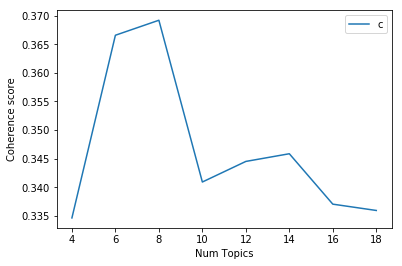

```python
# Show graph
limit=20; start=4; step=2;
x = range(start, limit, step)
plt.plot(x, coherence_values)
plt.xlabel("Num Topics")
plt.ylabel("Coherence score")
plt.legend(("coherence_values"), loc='best')
plt.show()
```

```python
# Print the coherence scores
for m, cv in zip(x, coherence_values):
    print("Num Topics =", m, " has Coherence Value of", round(cv, 4))
```

```
Num Topics = 4  has Coherence Value of 0.3347
Num Topics = 6  has Coherence Value of 0.3666
Num Topics = 8  has Coherence Value of 0.3692
Num Topics = 10  has Coherence Value of 0.3409
Num Topics = 12  has Coherence Value of 0.3445
Num Topics = 14  has Coherence Value of 0.3459
Num Topics = 16  has Coherence Value of 0.3371
Num Topics = 18  has Coherence Value of 0.336
```

### Optimal number of topics in our case is 8

```python
model_list[2]
```

```
<gensim.models.ldamodel.LdaModel at 0x1211714e0>
```

```python
# Select the model and print the topics
optimal_model = model_list[2]
model_topics = optimal_model.show_topics(formatted=False)
pprint(optimal_model.print_topics(num_words=10))
```

```
[(0,
  '0.011*"not" + 0.010*"stop" + 0.009*"people" + 0.008*"make" + 0.008*"do" + '
  '0.007*"need" + 0.006*"climate_change" + 0.006*"energy" + 0.006*"trump" + '
  '0.005*"waste"'),
 (1,
  '0.010*"climate_change" + 0.009*"human" + 0.009*"would" + 0.009*"climate" + '
  '0.008*"nothing" + 0.008*"people" + 0.008*"change" + 0.008*"impact" + '
  '0.007*"carbon" + 0.007*"power"'),
 (2,
  '0.013*"go" + 0.008*"think" + 0.007*"less" + 0.007*"carbon" + 0.007*"good" + '
  '0.006*"make" + 0.006*"source" + 0.006*"get" + 0.006*"climate" + '
  '0.006*"energy"'),
 (3,
  '0.020*"climate_change" + 0.012*"do" + 0.011*"not" + 0.010*"go" + '
  '0.010*"earth" + 0.009*"change" + 0.008*"people" + 0.007*"stop" + '
  '0.007*"capitalism" + 0.006*"nothing"'),
 (4,
  '0.016*"reduce" + 0.013*"emission" + 0.008*"thing" + 0.007*"not" + '
  '0.007*"carbon" + 0.007*"try" + 0.006*"control" + 0.006*"do" + 0.006*"child" '
  '+ 0.006*"population"'),
 (5,
  '0.012*"not" + 0.009*"climate_change" + 0.008*"use" + 0.008*"solution" + '
  '0.008*"do" + 0.007*"make" + 0.007*"thing" + 0.007*"climate" + '
  '0.006*"change" + 0.006*"energy"'),
 (6,
  '0.010*"not" + 0.009*"change" + 0.007*"need" + 0.006*"year" + 0.006*"do" + '
  '0.006*"energy" + 0.005*"can" + 0.005*"think" + 0.005*"start" + 0.005*"fix"'),
 (7,
  '0.015*"stop" + 0.010*"not" + 0.009*"people" + 0.007*"do" + 0.007*"gas" + '
  '0.007*"atmosphere" + 0.006*"emission" + 0.006*"less" + 0.006*"eat" + '
  '0.006*"reduce"')]
```

```python
# Visualize the topics
pyLDAvis.enable_notebook()
vis = pyLDAvis.gensim.prepare(optimal_model, corpus, id2word)
vis
```

[interactive chart not shown]

### Calculate the most dominant topic for each answer

To find that, we find the topic number that has the highest percentage contribution in that document

```python
def format_topics_sentences(ldamodel=optimal_model, corpus=corpus, texts = opinions):
    # Init output
    sent_topics_df = pd.DataFrame()

    # Get main topic in each document
    for i, row in enumerate(ldamodel[corpus]):
        row = sorted(row, key=lambda x: (x[1]), reverse=True)
        # Get the Dominant topic, Perc Contribution and Keywords for each document
        for j, (topic_num, prop_topic) in enumerate(row):
            if j == 0:  # => dominant topic
                wp = ldamodel.show_topic(topic_num)
                topic_keywords = ", ".join([word for word, prop in wp])
                sent_topics_df = sent_topics_df.append(pd.Series([int(topic_num), round(prop_topic,4), topic_keywords]), ignore_index=True)
            else:
                break
    sent_topics_df.columns = ['Dominant_Topic', 'Perc_Contribution', 'Topic_Keywords']

    # Add original text to the end of the output
    contents = pd.Series(texts)
    sent_topics_df = pd.concat([sent_topics_df, contents], axis=1)
    return(sent_topics_df)
```

```python
df_topic_sents_keywords = format_topics_sentences(ldamodel=optimal_model, corpus=corpus, texts=opinions)

# Format
df_dominant_topic = df_topic_sents_keywords.reset_index()
df_dominant_topic.columns = ['Document_No', 'Dominant_Topic', 'Topic_Perc_Contrib', 'Topic_Keywords', 'Opinion']

# Show
df_dominant_topic.head(10)
```

|  | Document_No | Dominant_Topic | Topic_Perc_Contrib | Topic_Keywords | Opinion |
| --- | --- | --- | --- | --- | --- |
| 0 | 0 | 6.0 | 0.5867 | not, change, need, year, do, energy, can, thin... | Government incentives to upgrade coal fired po... |
| 1 | 1 | 0.0 | 0.8749 | not, stop, people, make, do, need, climate_cha... | Keep encouraging regulations reducing pollutan... |
| 2 | 2 | 1.0 | 0.8749 | climate_change, human, would, climate, nothing... | The eruption of two supervolcanoes would take ... |
| 3 | 3 | 4.0 | 0.8184 | reduce, emission, thing, not, carbon, try, con... | If every human being on the planet dropped dea... |
| 4 | 4 | 1.0 | 0.9786 | climate_change, human, would, climate, nothing... | There is nothing we can do as individuals. No ... |
| 5 | 5 | 3.0 | 0.9453 | climate_change, do, not, go, earth, change, pe... | Its okay to accept the facts even when the fac... |
| 6 | 6 | 1.0 | 0.9027 | climate_change, human, would, climate, nothing... | A couple of super volcanoes would be immediate... |
| 7 | 7 | 6.0 | 0.9485 | not, change, need, year, do, energy, can, thin... | Placing hope in random natural disasters seems... |
| 8 | 8 | 3.0 | 0.9708 | climate_change, do, not, go, earth, change, pe... | If people truly gave a shit about the future f... |
| 9 | 9 | 7.0 | 0.9726 | stop, not, people, do, gas, atmosphere, emissi... | We have to act now as strongly as possible to ... |

Sometimes just the topic keywords may not be enough to make sense of what a topic is about. So, to help with understanding the topic, you can find the documents a given topic has contributed to the most and infer the topic by reading that document.

```python
# Group top 5 sentences under each topic
sent_topics_sorted = pd.DataFrame()

sent_topics_outdf_grpd = df_topic_sents_keywords.groupby('Dominant_Topic')

for i, grp in sent_topics_outdf_grpd:
    sent_topics_sorted = pd.concat([sent_topics_sorted,
                                             grp.sort_values(['Perc_Contribution'], ascending=[0]).head(1)],
                                            axis=0)

# Reset Index
sent_topics_sorted.reset_index(drop=True, inplace=True)

# Format
sent_topics_sorted.columns = ['Topic_Num', "Topic_Perc_Contrib", "Keywords", "Text"]

# Show
sent_topics_sorted.head(8)
```

|  | Topic_Num | Topic_Perc_Contrib | Keywords | Text |
| --- | --- | --- | --- | --- |
| 0 | 0.0 | 0.9849 | not, stop, people, make, do, need, climate_cha... | TAKE PERSONAL RESPONSIBILITY IN EVERYTHING : -... |
| 1 | 1.0 | 0.9931 | climate_change, human, would, climate, nothing... | Heres what the official position of the AAAS (... |
| 2 | 2.0 | 0.9917 | go, think, less, carbon, good, make, source, g... | In the scientific papers which considered clim... |
| 3 | 3.0 | 0.9936 | climate_change, do, not, go, earth, change, pe... | Three things: 1) Deal with the fact that its h... |
| 4 | 4.0 | 0.9786 | reduce, emission, thing, not, carbon, try, con... | The only real solution for climate change and ... |
| 5 | 5.0 | 0.9928 | not, climate_change, use, solution, do, make, ... | What should be done about climate change? In o... |
| 6 | 6.0 | 0.9801 | not, change, need, year, do, energy, can, thin... | Es gibt viele Sachen zu tun (nachhaltiger zu l... |
| 7 | 7.0 | 0.9932 | stop, not, people, do, gas, atmosphere, emissi... | The atmosphere does not necessarily have to ge... |

#### # what is the most illustrative opinion of Topic nr 1?

```python
sent_topics_sorted[sent_topics_sorted['Topic_Num']==1].iloc[0,3]
```

```
'Heres what the official position of the AAAS (American Association for the Advancement of Science) on climate change: "Surveys show that many Americans think climate change is still a topic of significant scientific disagreement.[i] Thus, it is important and increasingly urgent for the public to kn…
```

#### # what is the most illustrative opinion of Topic nr 7?

```python
sent_topics_sorted[sent_topics_sorted['Topic_Num']==7].iloc[0,3]
```

```
'The atmosphere does not necessarily have to get cleaner every year, but it must get less dirty than our expectations. So how can Airshares appreciate in value as the atmosphere beats our expectations? How can Airshares depreciate in value as the atmosphere doesnt meet our expectations? Simple answe…
```

#### # what is the most illustrative opinion of Topic nr 6?

```python
sent_topics_sorted[sent_topics_sorted['Topic_Num']==6].iloc[0,3]
```

```
'Es gibt viele Sachen zu tun (nachhaltiger zu leben) und nicht zu tun (kein Plastik mehr zu produzieren/ zu verwenden).... Das sind nur einzelne Beispiele... Es gibt so viele von denen!!!! Wir sind aber auch viele Menschen auf der Erde!!!! Es gibt viel zu tun Leute!!! Also ran an die Arbeit!!'
```